# IPTW estimation applied in NAMCS NSAID data

UNC EPID 722: Dr. Alan Brookhart

January 26, 2016

### 0.0.1 Specify packages

```r
#install.packages(c("foreign", "foreach", "ggplot2"))
library(foreign)
library(foreach)
library(ggplot2)

set.seed(101) # set seed to produce same results in simulation below
```

# 1 read in NAMCS data – will need to correct the path

```r
getwd() # find working directory for this session

ns=read.dta("../../data/nsaid008b.dta") # read in data. relative to the working directory go up 2 levels and into 'data' folder to read data.
# Otherwise specify full path of data location. for example a path could be c:\temp\nsaid008b.dta
# ns=read.dta("../data/nsaid008b.dta") # ignore. for debugging only.
```

# 2 Simulate outcome using logistic regression

```r
ns$pbleed=1/(1+exp(-(-6.75 + .6*ns$contanticoag + 1*ns$tobacco_imp + .5*ns$contsteroids +
                       .2*ns$contaspirin + .7*ns$arthrtis + .07*ns$age + .3*ns$male +
                       .02*ns$raceblkoth- .3*ns$newcox2 )))

ns$bleed = rbinom(size=1,n=nrow(ns),p=ns$pbleed)

sim.coef = coef(glm(bleed ~ contanticoag + tobacco_imp + contsteroids + contaspirin + arthrtis + age + male + raceblkoth + newcox2, data=ns))
sim.coef
```

```
##  (Intercept) contanticoag  tobacco_imp contsteroids  contaspirin
## -0.191177320  0.284077313  0.070754255 -0.005831485  0.046928059
##     arthrtis          age         male   raceblkoth      newcox2
##  0.059348201  0.005412938  0.014528154 -0.022584583 -0.027373623
```

```r
sim.coef[length(sim.coef)] # get the last coefficient, the stated effect
```

```
##     newcox2
## -0.02737362
```

# 3 What is true E[Y(1)]-E[Y(0)] in our population, the causal risk difference?

```r
pbleed.0=1/(1+exp(-(-6.75 + .6*ns$contanticoag + 1*ns$tobacco_imp + .5*ns$contsteroids +
                      .2*ns$contaspirin + .7*ns$arthrtis + .07*ns$age + .3*ns$male +
                      .02*ns$raceblkoth)))

pbleed.1=1/(1+exp(-(-6.75 + .6*ns$contanticoag + 1*ns$tobacco_imp + .5*ns$contsteroids +
                      .2*ns$contaspirin + .7*ns$arthrtis + .07*ns$age + .3*ns$male +
                      .02*ns$raceblkoth - 0.3)))

mean(pbleed.1)
```

```
## [1] 0.0750205
```

```r
mean(pbleed.0)
```

```
## [1] 0.09507942
```

```r
mean(pbleed.1)-mean(pbleed.0)
```

```
## [1] -0.02005892
```

If you conducted a randomized trial in this context you would expect 2.006 fewer cases of bleeding per 100 people in the treated group (newcox2=1) compared to the untreated group (assuming all relavant conditions hold true, including “positivity, well-defined exposures, correctly specified models, and no unmeasured confounding or selection bias” (5)).

# 4 What is E[Y(1)]/E[Y(0)], the true causal risk ratio?

```r
mean(pbleed.1)/mean(pbleed.0)
```

```
## [1] 0.7890299
```

# 5 what is E[Y(1)|X=1]-E[Y(0)|X=1]?

```r
mean(pbleed.1[ns$newcox2==1])-mean(pbleed.0[ns$newcox2==1])
```

```
## [1] -0.0268157
```

# 6 Estimate the (unknown) propensity score, and plot the density by treatment group

## 6.1 Look for violations of positivity

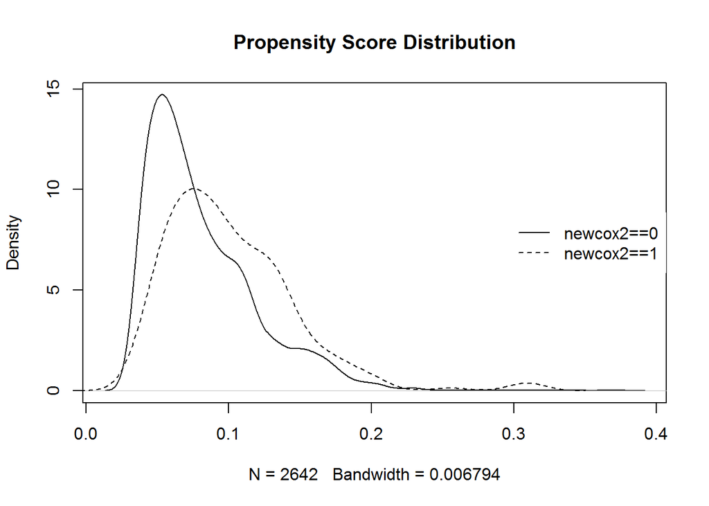

```r
glm.out=glm(newcox2~contanticoag+tobacco_imp+contsteroids+contaspirin+arthrtis+age+male+raceblkoth,family=binomial,data=ns)
ns$ps=predict(glm.out,type="response")

plot(density(ns$ps[ns$newcox2==0]),lty=1,main="Propensity Score Distribution")
lines(density(ns$ps[ns$newcox2==1]),lty=2)
legend("right",c("newcox2==0","newcox2==1"),lty=c(1,2),box.col=NA)
```

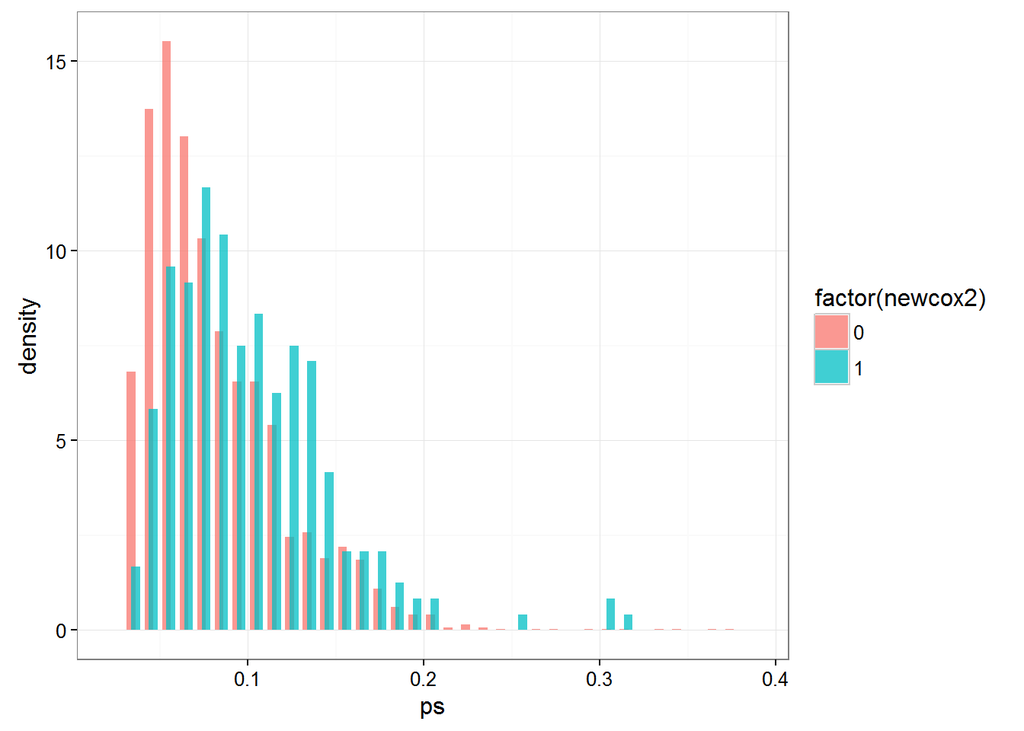

```r
ggplot(data=ns, aes(x=ps,group=factor(newcox2),
                    fill=factor(newcox2))) +
  geom_histogram(aes(y=..density..),
                 alpha = 0.75,
                 binwidth=0.01,
                 position = position_dodge(width=0.005)) +
  theme_bw()
```

```r
# Demo: show how to make panels in ggplot
levels(factor(ns$male)) # double check current ordering of values for male
```

```
## [1] "0" "1"
```

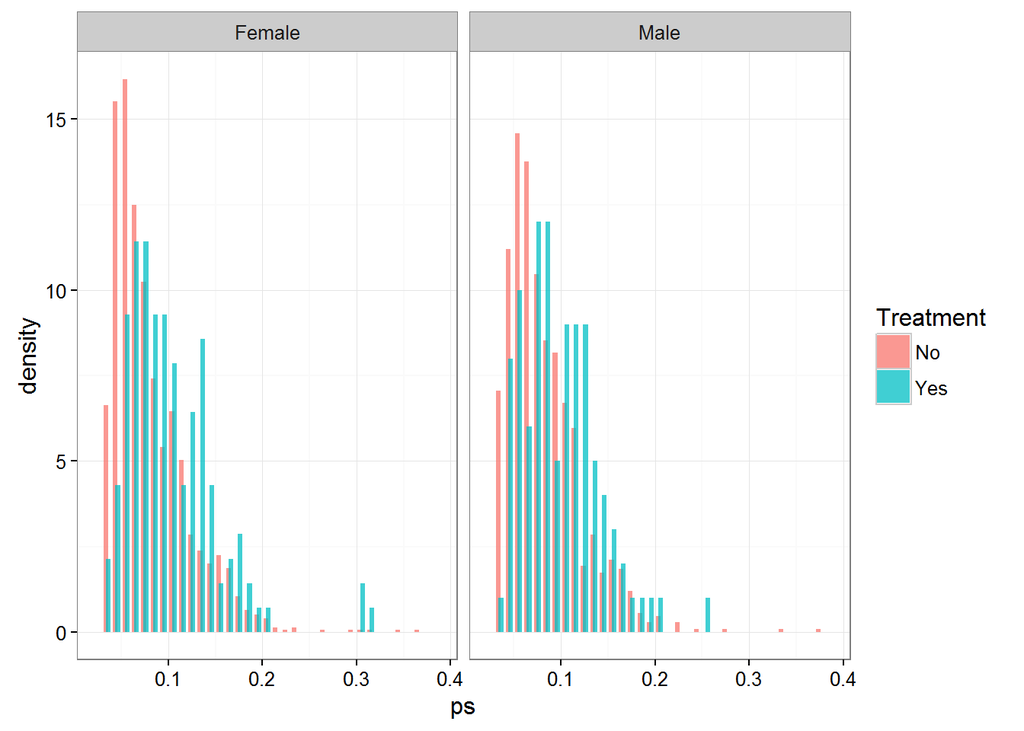

```r
ns$male.f = factor(ns$male, labels=c("Female", "Male") )

ggplot(data=ns, aes(x=ps,group=factor(newcox2),
                    fill=factor(newcox2))) +
  geom_histogram(aes(y=..density..),
                 alpha = 0.75,
                 binwidth=0.01,
                 position = position_dodge(width=0.005)) +
  theme_bw() +
  facet_wrap(~male.f) +
  scale_fill_discrete(name="Treatment",
                            breaks=c(0, 1),
                            labels=c("No", "Yes"))
```

# 7 compute IPTW and SMRW weights

```r
ns$iptw=ns$newcox2/ns$ps+(1-ns$newcox2)/(1-ns$ps)
ns$smrw=ns$newcox2+(1-ns$newcox2)*ns$ps/(1-ns$ps)
```

# 8 Table 1

```r
covs=c("male","age","diabetes","arthrtis","copd",
       "reas1digest","tobacco_imp","contsteroids")
ret=foreach(var=covs,.combine="rbind") %do%
  c(mean(ns[ns$newcox2==0,var]),mean(ns[ns$newcox2==1,var]))
row.names(ret)<-covs
colnames(ret)<-c("Old NSAIDS","Cox-2 Sel NSAIDs")
round(ret,2)
```

```
##              Old NSAIDS Cox-2 Sel NSAIDs
## male               0.41             0.42
## age               47.30            53.43
## diabetes           0.08             0.13
## arthrtis           0.30             0.47
## copd               0.02             0.03
## reas1digest        0.03             0.04
## tobacco_imp        0.15             0.18
## contsteroids       0.00             0.02
```

# 9 Compute Table 1 statistics for IPTW sample

```r
ret=foreach(var=covs,.combine="rbind") %do%
  c(sum(ns[,var]*ns$iptw*ns$newcox2),sum(ns[,var]*ns$iptw*(1-ns$newcox2)))/nrow(ns)
row.names(ret)<-covs
colnames(ret)<-c("Old NSAIDS","Cox-2 Sel NSAIDs")
round(ret,2)
```

```
##              Old NSAIDS Cox-2 Sel NSAIDs
## male               0.41             0.41
## age               48.10            47.83
## diabetes           0.13             0.08
## arthrtis           0.33             0.31
## copd               0.02             0.02
## reas1digest        0.05             0.03
## tobacco_imp        0.15             0.15
## contsteroids       0.01             0.01
```

# 10 Unweighted regression, crude

```r
m.unwt = glm(bleed~newcox2,data=ns)
summary(m.unwt)
```

```
##
## Call:
## glm(formula = bleed ~ newcox2, data = ns)
##
## Deviance Residuals:
##     Min       1Q   Median       3Q      Max
## -0.1167  -0.0969  -0.0969  -0.0969   0.9031
##
## Coefficients:
##             Estimate Std. Error t value Pr(>|t|)
## (Intercept)  0.09690    0.00580  16.707   <2e-16 ***
## newcox2      0.01977    0.02010   0.984    0.325
## ---
## Signif. codes:  0 '***' 0.001 '**' 0.01 '*' 0.05 '.' 0.1 ' ' 1
##
## (Dispersion parameter for gaussian family taken to be 0.08886385)
##
##     Null deviance: 256.01  on 2881  degrees of freedom
## Residual deviance: 255.93  on 2880  degrees of freedom
## AIC: 1206.4
##
## Number of Fisher Scoring iterations: 2
```

```r
coef.unwt = coef(m.unwt)
```

In unweighted model, the coefficient for the treatment in the model, 0.0197704 suggests that the treated group (newcox2=1) had 1.977 additional cases of bleeding (bleed=1) per 100 people compared to the untreated group.

# 11 IPT weighted, to get SE correct must bootstrap or use GEE

```r
m.iptw = glm(bleed~newcox2,weight=iptw,data=ns)
summary(m.iptw)
```

```
##
## Call:
## glm(formula = bleed ~ newcox2, data = ns, weights = iptw)
##
## Deviance Residuals:
##     Min       1Q   Median       3Q      Max
## -0.4274  -0.1069  -0.1050  -0.1039   3.2342
##
## Coefficients:
##              Estimate Std. Error t value Pr(>|t|)
## (Intercept)  0.101383   0.007515  13.490   <2e-16 ***
## newcox2     -0.021981   0.010685  -2.057   0.0398 *
## ---
## Signif. codes:  0 '***' 0.001 '**' 0.01 '*' 0.05 '.' 0.1 ' ' 1
##
## (Dispersion parameter for gaussian family taken to be 0.1628144)
##
##     Null deviance: 469.59  on 2881  degrees of freedom
## Residual deviance: 468.91  on 2880  degrees of freedom
## AIC: 2152.8
##
## Number of Fisher Scoring iterations: 2
```

```r
coef.iptw = coef(m.iptw)
```

Now, the estimate, -0.021981 is closer to the simulated value, -0.0273736.

# 12 SMR weighted, to get SE correct must bootstrap or use GEE

```r
m.smrw = glm(bleed~newcox2,weight=smrw,data=ns)
summary(m.smrw)
```

```
##
## Call:
## glm(formula = bleed ~ newcox2, data = ns, weights = smrw)
##
## Deviance Residuals:
##      Min        1Q    Median        3Q       Max
## -0.11667  -0.05035  -0.04032  -0.03355   0.88333
##
## Coefficients:
##             Estimate Std. Error t value Pr(>|t|)
## (Intercept)  0.15062    0.00895  16.830  < 2e-16 ***
## newcox2     -0.03395    0.01267  -2.681  0.00739 **
## ---
## Signif. codes:  0 '***' 0.001 '**' 0.01 '*' 0.05 '.' 0.1 ' ' 1
##
## (Dispersion parameter for gaussian family taken to be 0.01928225)
##
##     Null deviance: 55.671  on 2881  degrees of freedom
## Residual deviance: 55.533  on 2880  degrees of freedom
## AIC: 3456.1
##
## Number of Fisher Scoring iterations: 2
```

```r
coef.smrw = coef(m.smrw)
```

Estimate for effect, -0.0339554, now even larger than the iptw, -0.021981, because standardized to sicker patients who could benefit more from treatment.

Assigned reading

1. Austin PC. An Introduction to Propensity Score Methods for Reducing the Effects of Confounding in Observational Studies. *Multivar. Behav. Res.* [electronic article]. 2011;46(3):399–424. (http://www.tandfonline.com/doi/abs/10.1080/00273171.2011.568786)

2. Brookhart MA, StC<rmer T, Glynn RJ, et al. Confounding Control in Healthcare Database Research: Challenges and Potential Approaches. *Med. Care* [electronic article]. 2010;48:S114–S120. (http://content.wkhealth.com/linkback/openurl?sid=WKPTLP:landingpage&an=00005650-201006001-00018)

3. Lunceford JK, Davidian M. Stratification and weighting via the propensity score in estimation of causal treatment effects: A comparative study. *Stat. Med.* [electronic article]. 2004;23(19):2937–2960. (http://doi.wiley.com/10.1002/sim.1903)

4. Rosenbaum PR, Rubin DB. Reducing Bias in Observational Studies Using Subclassification on the Propensity Score. *J. Am. Stat. Assoc.* 1984;79(387):516.

5. Buchanan AL, Hudgens MG, Cole SR, et al. Worth the Weight: Using Inverse Probability Weighted Cox Models in AIDS Research. *AIDS Res. Hum. Retroviruses* [electronic article]. 2014;30(12):1170–1177. (http://online.liebertpub.com/doi/abs/10.1089/aid.2014.0037)